# R을 이용한 말뭉치 자료 전처리 (3회)

### 3회차에서 다루는 내용

- 라이브러리(혹은 패키지) 설치 및 로딩
- 파일 읽고 쓰기
- 파일 정제하기
- json 파일 읽고 정제하기

### 라이브러리 설치와 구동

- 패키지(혹은 라이브러리)란 특정한 작업을 위해 사전에 작성한 함수들을 모아놓은 함수들의 모음집
- 텍스트 파일을 읽어 처리하고 저장하는 일련의 과정은 R의 내장 함수(1회차에서 소개한 함수들과 같이 R 자체에 내장되어 있는 함수)로 진행하는 것이 가능하나, 특수한 파일을 읽고 처리하거나 보다 복잡한 작업을 할 때에는 외부 라이브러리를 설치하는 것이 필요.
  - (* 본 강의에서는 외부 라이브러리의 설치를 최소화하여 내장 함수 중심으로 진행.)

본 강의에서 사용할 외부 패키지는 *jsonlite*으로, 모두의 말뭉치 데이터 기본 포맷인 json 파일을 처리할 때 필요한 여러 함수들을 담고 있다.

#### 라이브러리 설치

라이브러리 설치는 두 가지 방법으로 할 수 있다.

- 콘솔창에 **install.packages()** 함수를 입력하거나 (# 기호를 빼고 실행)

```r
# install.packages("jsonlite")
```

- Rstudio 오른쪽 하단 패널에서 Packages 메뉴로 가서 install 버튼 누른 후 검색 후 설치할 수 있다.

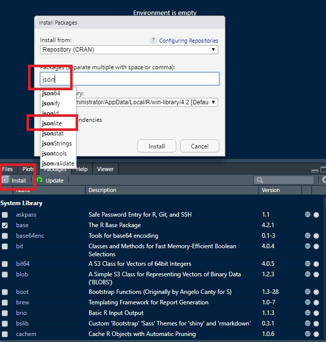

#### 라이브러리 구동

설치한 라이브러리는 로딩 단계를 거친 후에 사용할 수 있다. 라이브러리의 로딩은 **library(<패키지명>)** 명령을 이용한다.

```r
library(jsonlite)
```

- 설치한 라이브러리에 대한 도움말은 Rstudio 오른쪽 하단 패널의 검색창에 라이브러리 이름을 입력하면 Help 창에 설명이 나타난다. 검색창에는 라이브러리뿐 아니라 개별 함수에 대한 설명 검색도 가능하다.

[figure not shown]

- 보다 다양한 패키지와 패키지 내 함수들에 대한 설명은 RDocumentation(https://www.rdocumentation.org/)에서 찾아볼 수 있다.

### 텍스트 파일 읽기, 쓰기

#### 파일 읽기

디스크에 저장된 파일을 읽을 때는 **readLines()** 함수를 사용한다. 파일을 행 단위로 읽어 문자열 벡터를 만든다.

```r
target_f <- "data/실습파일/실습파일_001.txt"
txt <- readLines(target_f)

print(txt[1:3])
```

```
## [1] "전에는 그냥 열심히 당당하게 살았는데 갑자기 약해져 전과는 정반대의 모습을 지니게 되었다는 것이다."
## [2] "그러면서 계속 이 병원, 저 병원을 다니거나 주위 사람들에게 도움을 구하지만 뾰족한 답은 찾을 수 없다."
## [3] "그럴 경우 내가 환자들에게 주로 하는 방법은 우선 모든 판단을 가급적 스스로 하게 하고 그들의 꿈을 살펴보는 것이다."
```

- 라인 1: 읽을 파일의 위치 경로를 변수 *target_f*에 할당한다. 파일의 경로는 사용하는 시스템마다 다를 수 있으므로, 직접 입력하는 대신 윈도우 탐색기에서 파일의 속성 정보를 열어 위치 경로를 가져오는 방법도 있다. 이 때 파일 경로 구분자가 ‘**\**’로 되어 있으면’**/**’로 바꾸어야 한다. (예: ‘C:\Users\Administrator’ -> ‘C:/Users/Administrator’)
- 라인 2: 파일을 읽어 변수 *txt*에 저장한다.
- 라인 3: *txt*에 저장된 텍스트에서 1행에서 3행까지만(*txt[1:3]*) 출력한다.

만약 텍스트 파일의 크기가 너무 커서 일부 행만 읽어서 내용을 확인하고 싶으면 **readLines()** 함수에 **n** 인자를 부여하면 된다.

```r
target_f <- "data/실습파일/실습파일_001.txt"
txt <- readLines(target_f, n = 3)

print(txt)
```

```
## [1] "전에는 그냥 열심히 당당하게 살았는데 갑자기 약해져 전과는 정반대의 모습을 지니게 되었다는 것이다."
## [2] "그러면서 계속 이 병원, 저 병원을 다니거나 주위 사람들에게 도움을 구하지만 뾰족한 답은 찾을 수 없다."
## [3] "그럴 경우 내가 환자들에게 주로 하는 방법은 우선 모든 판단을 가급적 스스로 하게 하고 그들의 꿈을 살펴보는 것이다."
```

- 라인 2: **n**에 3을 주어 3행까지만 읽게 한다.
- 라인 3: *txt* 전체를 출력해도 3행까지만 나온다.

#### 파일 쓰기

변수에 저장된 내용을 디스크에 파일로 쓰고 싶을 때에는 **writeLines()** 함수를 사용한다. 사용 방법은 **readLines()**와 유사하다.

```r
target_f <- "data/실습파일/쓰기_실습파일_001.txt"
writeLines(text = txt, con = target_f)

filelist <- list.files(path = "data/실습파일", pattern = ".")
print(filelist)
```

```
## [1] "regex_practice_text.txt" "실습파일_001.txt"
## [3] "실습파일_001_cp949.txt"  "실습파일_001_utf-8.txt"
## [5] "실습파일_002.txt"        "실습파일_003.txt"
## [7] "쓰기_실습파일_001.txt"
```

- 라인 1: 새로 만들 파일의 위치 경로와 파일 이름을 정해 *target_f*에 할당한다.
- 라인 2: **writeLines()** 함수로 앞서 만든 txt 변수의 내용을 *target_f*에 저장된 위치에 파일로 내보낸다. 내보낼 텍스트는 **text** 인자에, 저장 위치는 **con** 인자에 넣는다.
- 라인 4: 새로 만든 파일이 원하는 위치에 만들어졌는지 확인하기 위해 그 파일이 저장된 폴더 내의 전체 파일 목록을 가져온다. 특정 폴더 내의 파일 목록을 가져올 때 사용하는 함수가 **list.files()**이다. **path**에는 폴더 경로를, **pattern**에는 파일 검색을 위한 검색 패턴을 넣는다. 모든 파일을 가져올 때는 ’.’을 사용한다.
- 라인 5: 파일 목록을 출력한다. 새로 만든 파일이 7번째에 있음을 알 수 있다.

#### 여러 파일 읽기

동일한 작업을 여러 번 반복할 때 가장 많이 사용하는 구문이 **for** 문이다. **for** 문의 기본 구문은 다음과 같다.

```r
# for ((elem in elements) {
#  함수(elem): 반복할 내용
# }
```

*elements*에 있는 요소들을 하나씩 가져와서 변수(*elem*)에 넣고, { } 내에서 이 변수를 처리한 후 결과를 반환한다. for 문의 작동을 보여주는 쉬운 예는 다음과 같다. 1에서 10까지의 10개 요소를 하나씩 가져와서 변수 *i*에 할당한 후 { }내에서 그 변수를 출력(**print()**)하는 간단한 예시이다.

```r
for (i in 1:10){
  print(i)
}
```

```
## [1] 1
## [1] 2
## [1] 3
## [1] 4
## [1] 5
## [1] 6
## [1] 7
## [1] 8
## [1] 9
## [1] 10
```

- 다음은 위의 예시와 거의 동일하나 변수 *i*를 그냥 출력하지 않고 10을 곱한 후 값을 출력하는 예시이다.

```r
for (i in 1:10){
  print(i * 10)
}
```

```
## [1] 10
## [1] 20
## [1] 30
## [1] 40
## [1] 50
## [1] 60
## [1] 70
## [1] 80
## [1] 90
## [1] 100
```

- 다음은 for 문에서 처리한 결과를 변수에 차례대로 할당하는 예시이다.

```r
nums <- c()

for (i in 1:10){
  nums <- c(nums, i)
  print(i)
}
```

```
## [1] 1
## [1] 2
## [1] 3
## [1] 4
## [1] 5
## [1] 6
## [1] 7
## [1] 8
## [1] 9
## [1] 10
```

```r
print(nums)
```

```
##  [1]  1  2  3  4  5  6  7  8  9 10
```

- 라인 1: *nums* 변수는 1부터 10까지 숫자를 순차적으로 담기 위한 그릇 역할을 한다. 이러한 빈 변수를 만들 때는 **c()**나 **list()**를 사용한다. **c()**는 담을 값의 구조가 단일 구조일 때, **list()**는 이중 구조일 때 사용한다.
- 라인 3-6: 1부터 10까지 하나씩 출력하되, 출력하기 전에 그 값을 *nums*라는 변수에 하나씩 추가한다.

특정 폴더에 저장된 여러 개의 파일을 한번에 읽을 때는 **list.files()**, **readLines()**, **file.path()**, **for** 문을 사용한다.

```r
target_dir <- "data/실습파일"
target_fs <- list.files(path = target_dir, pattern = ".")

all_texts <- list()

for (f in target_fs) {
  file_path <- file.path(target_dir, f)
  txt <- readLines(file_path)
  all_texts[[f]] <- txt
}

print(length(target_fs)); print(length(all_texts))
```

```
## [1] 7
```

```
## [1] 7
```

- 라인 1: 대상 폴더 경로를 *target_dir*에 할당한다.
- 라인 2: 주어진 폴더 내의 모든 파일과 하위 폴더 이름을 가져오는 **list.files()** 함수로 target_dir 내의 모든 파일들의 목록을 가져온다. 이 때 특정 파일 이름에 한정하지 않고 전체 파일을 가져오기 위해 **pattern**에 ‘.’ 값을 준다. 목록을 *target_fs*에 저장한다.
- 라인 4: 전체 파일들을 읽은 결과를 담기 위한 *all_text* 변수를 생성한다. 변수의 타입은 이중 구조를 가진 리스트 타입이다. 하나의 텍스트는 여러 행으로 되어 있고, **readLines()**는 행 단위로 텍스트를 읽어오므로 이러한 이중 구조를 반영하기 위해 리스트 변수를 만든다.
- 라인 7: **for** 문을 시작한다. 파일 이름 목록인 *target_fs*에서 파일 이름을 하나씩 가져와서 변수 *f*에 할당한다.
- 라인 8: **file.path(<경로명>, <파일명>)**로 파일 이름과 폴더 경로를 합해서 최종 경로를 만들어 *file_path*에 저장한다.
- 라인 9: **readLines()**로 파일을 읽어 *txt*에 저장한다.
- 라인 10: *txt* 변수에 저장된 값을 *all_texts* 변수에 저장한다. [[]]는 리스트의 인덱싱을 위한 것으로, 변수값의 범위를 지정하는 []와 동일한 역할을 한다. 여기서는 파일명을 인덱스값으로 준다.
- 라인 12: 파일의 개수와 읽은 파일의 개수가 같은지 확인하기 위해 두 변수를 각각 출력한다.

읽은 파일들의 내용이 담긴 *all_texts*를 출력하면 다음과 같다. 각 파일의 내용과 파일의 이름(*$regex_practice_text.txt*)이 함께 출력됨을 볼 수 있다.

```r
print(all_texts)
```

```
## $regex_practice_text.txt
##  [1] "Social worker: Have you been keeping up with your journal?"
##  [2] "사회복지사: 일기는 계속 쓰고 계신가요?"
##  [3] "Joker: Everyday."
##  [4] "조커: 매일이요."
##  [5] "Social worker: Great. Did you bring it with you?"
##  [6] "사회복지사: 잘 하셨어요. 일기 가지고 오셨나요?"
##  [7] "Joker: (dodging the subject) I'm sorry. Did I bring what?"
##  [8] "조커: (못 들은 체하며) 죄송합니다. 뭐라고 하셨죠?"
##  [9] "Social worker: (impatient; she doesn't have time for this) Arthur, last time I asked you to bring your journal with you. For these appointments. Do you have it?"
## [10] "사회복지사: (신경질적으로; 그녀는 이러고 있을 시간이 없다.) 아서, 일기장을 가지고 오라고 지난 번에 부탁했잖아요. 이번에 만날 때. 가지고 왔나요?"
## [11] "Joker: Yes ma'am."
## [12] "조커: 네."
## [13] "\t[From the movie <Joker>. 영화 <조커>에서]"
##
```

[output cut: 110 more lines]

읽은 파일들 중 문자 인코딩이 cp949인 것은 깨진 문자로 보인다. 이 cp949 인코딩 파일을 제외하고 전체 파일을 다시 읽을 수 있다.

```r
target_dir <- "data/실습파일"
target_fs <- list.files(path = target_dir, pattern = ".")
remove_f <- grep(pattern = "cp949", x = target_fs)
target_fs_1 <- target_fs[-remove_f]

all_texts_1 <- list()

for (f in target_fs_1) {
  file_path <- file.path(target_dir, f)
  txt <- readLines(file_path)
  all_texts_1[[f]] <- txt
}
```

- 라인 3: 파일 목록 *target_fs*에서 이름에 cp949가 들어있는 파일의 위치를 **grep()**으로 가져온 후 변수 *remove_f*에 할당한다.
- 라인 4: 전체 파일 목록 *target_fs*에서 제외할 파일의 위치값을 ’-’로 나타내어 해당 위치에 있는 파일명을 목록에서 제외한다.

결과를 출력하면 다음과 같다.

```r
print(all_texts_1)
```

```
## $regex_practice_text.txt
##  [1] "Social worker: Have you been keeping up with your journal?"
##  [2] "사회복지사: 일기는 계속 쓰고 계신가요?"
##  [3] "Joker: Everyday."
##  [4] "조커: 매일이요."
##  [5] "Social worker: Great. Did you bring it with you?"
##  [6] "사회복지사: 잘 하셨어요. 일기 가지고 오셨나요?"
##  [7] "Joker: (dodging the subject) I'm sorry. Did I bring what?"
##  [8] "조커: (못 들은 체하며) 죄송합니다. 뭐라고 하셨죠?"
##  [9] "Social worker: (impatient; she doesn't have time for this) Arthur, last time I asked you to bring your journal with you. For these appointments. Do you have it?"
## [10] "사회복지사: (신경질적으로; 그녀는 이러고 있을 시간이 없다.) 아서, 일기장을 가지고 오라고 지난 번에 부탁했잖아요. 이번에 만날 때. 가지고 왔나요?"
## [11] "Joker: Yes ma'am."
## [12] "조커: 네."
## [13] "\t[From the movie <Joker>. 영화 <조커>에서]"
##
```

[output cut: 87 more lines]

만약 파일별로 구분하지 않고 전체 파일을 읽어 하나의 텍스트로 처리하려면 *all_texts* 변수 타입을 **list()**가 아닌 **c()**로 지정하면 된다.

```r
target_dir <- "data/실습파일"
target_fs <- list.files(path = target_dir, pattern = ".")
remove_f <- grep(pattern = "cp949", x = target_fs)
target_fs_2 <- target_fs[-remove_f]

all_texts_2 <- c()

for (f in target_fs_2) {
  file_path <- file.path(target_dir, f)
  txt <- readLines(file_path)
  all_texts_2 <- c(all_texts_2, txt)
}
```

- 라인 6: *all_texts_2* 변수 타입을 **c()**로 설정한다.
- 라인 11: *txt*에 저장된 파일 내용, 즉 행들을 *all_texts_2* 변수에 순차적으로 추가한다.

*all_texts_2*를 일부만 출력하면 다음과 같다.

```r
print(all_texts_2[1:10])
```

```
##  [1] "Social worker: Have you been keeping up with your journal?"
##  [2] "사회복지사: 일기는 계속 쓰고 계신가요?"
##  [3] "Joker: Everyday."
##  [4] "조커: 매일이요."
##  [5] "Social worker: Great. Did you bring it with you?"
##  [6] "사회복지사: 잘 하셨어요. 일기 가지고 오셨나요?"
##  [7] "Joker: (dodging the subject) I'm sorry. Did I bring what?"
##  [8] "조커: (못 들은 체하며) 죄송합니다. 뭐라고 하셨죠?"
##  [9] "Social worker: (impatient; she doesn't have time for this) Arthur, last time I asked you to bring your journal with you. For these appointments. Do you have it?"
## [10] "사회복지사: (신경질적으로; 그녀는 이러고 있을 시간이 없다.) 아서, 일기장을 가지고 오라고 지난 번에 부탁했잖아요. 이번에 만날 때. 가지고 왔나요?"
```

#### 여러 파일을 읽으면서 텍스트 정제 작업하기

지금까지 배운 함수들을 이용해서 여러 파일들을 읽으면서 동시에 필요한 텍스트 처리 작업을 실행할 수 있다. 정규식을 이용하여 읽어온 파일들에서 1) 마침표, 물음표, 느낌표, 쉼표 등 4개의 구두점을 제거하고, 2) 괄호 속에 들어있는 문장을 제거하고, 3) 영화 대사에서 등장인물 이름(조커:, Joker: 등)을 제외한 결과를 얻는 방법은 다음과 같다.

```r
target_dir <- "data/실습파일"
target_fs <- list.files(path = target_dir, pattern = ".")
remove_f <- grep(pattern = "cp949", x = target_fs)
target_fs_3 <- target_fs[-remove_f]

all_texts_3 <- c()

for (f in target_fs_3) {
  file_path <- file.path(target_dir, f)
  txt <- readLines(file_path)
  txt_1 <- gsub(pattern = "\\.|\\!|\\?|,", replacement = "", x = txt) # 마침표, 느낌표, 물음표, 쉼표를 제거
  txt_1 <- gsub(pattern = "\\(.*\\)", replacement = "", x = txt_1) # 괄호와 괄호 속의 글자 삭제
  txt_1 <- gsub(pattern = "^.*: ", replacement = "", x = txt_1) # 행의 제일 앞에서 시작하여 : 로 끝나는 곳까지 제거
  all_texts_3 <- c(all_texts_3, txt_1)
}
```

결과를 출력하면 다음과 같다.

```r
print(all_texts_3[1:20])
```

```
##  [1] "Have you been keeping up with your journal"
##  [2] "일기는 계속 쓰고 계신가요"
##  [3] "Everyday"
##  [4] "매일이요"
##  [5] "Great Did you bring it with you"
##  [6] "잘 하셨어요 일기 가지고 오셨나요"
##  [7] " I'm sorry Did I bring what"
##  [8] " 죄송합니다 뭐라고 하셨죠"
##  [9] " Arthur last time I asked you to bring your journal with you For these appointments Do you have it"
## [10] " 아서 일기장을 가지고 오라고 지난 번에 부탁했잖아요 이번에 만날 때 가지고 왔나요"
## [11] "Yes ma'am"
## [12] "네"
## [13] "\t[From the movie <Joker> 영화 <조커>에서]"
## [14] "전에는 그냥 열심히 당당하게 살았는데 갑자기 약해져 전과는 정반대의 모습을 지니게 되었다는 것이다"
## [15] "그러면서 계속 이 병원 저 병원을 다니거나 주위 사람들에게 도움을 구하지만 뾰족한 답은 찾을 수 없다"
## [16] "그럴 경우 내가 환자들에게 주로 하는 방법은 우선 모든 판단을 가급적 스스로 하게 하고 그들의 꿈을 살펴보는 것이다"
## [17] "답이 밖에 없고 바로 자기 무의식에 있기 때문이다"
## [18] "무의식이 의식의 태도가 못마땅해 반란을 일으킨 것이 불안으로 나타나는 것이다"
## [19] "이때는 무의식이 의식에게 무슨 요구를 하고 있는지 의식의 태도를 어떻게 수정해야 하는지 무의식을 잘 살펴볼 필요가 있다"
## [20] "꿈은 무의식으로 가는 왕도라고 할 만큼 무의식을 살펴보는 데는 중요한 수단이다"
```

### json 파일 읽기

json 파일은 새로 설치한 **jsonlite** 패키지를 이용해서 읽어들인다. json 파일을 읽는 함수는 **jsonlite** 패키지 내에 있는 **read_json()** 함수이다.

먼저 **jsonlite** 패키지를 로딩한다.

```r
library(jsonlite)
```

#### 문어 말뭉치 파일의 구조

json 파일의 경로 위치를 설정하고 readLines()로 텍스트 파일을 읽는 것도 동일한 방식으로 파일을 읽는다.

```r
target_f <- "data/모두의말뭉치/국립국어원 문어 말뭉치(버전 1.0)/WARW1800000007.json"
json_obj <- read_json(target_f)
```

R 객체(변수)의 구조를 살펴볼 수 있는 str() 함수를 이용하여 읽어들인 json 파일의 구조를 살펴볼 수 있다.

```r
print(str(object = json_obj, max.level = 5, nchar.max = 50, list.len = 3))
```

```
## List of 3
##  $ id      : chr "WARW1800000007"
##  $ metadata:List of 7
##   ..$ title           : chr "국립국어원 문어 말뭉치 WARW1800000007"
##   ..$ creator         : chr "국립국어원"
##   ..$ distributor     : chr "국립국어원"
##   .. [list output truncated]
##  $ document:List of 1
##   ..$ :List of 3
##   .. ..$ id       : chr "WARW1800000007.1"
##   .. ..$ metadata :List of 4
##   .. .. ..$ title    : chr "이야기꾼 구연설화"
##   .. .. ..$ author   : chr "황인덕"
##   .. .. ..$ publisher: chr "박이정"
##   .. .. .. [list output truncated]
##   .. ..$ paragraph:List of 9762
##   .. .. ..$ :List of 2
##   .. .. .. ..$ id  : chr "WARW1800000007.1.1"
##   .. .. .. ..$ form: chr "01범보다 무서운 곶감"
##   .. .. ..$ :List of 2
##   .. .. .. ..$ id  : chr "WARW1800000007.1.2"
##   .. .. .. ..$ form: chr "화자를 처음 만나 이야기를 들으러 "| __truncated__
##   .. .. ..$ :List of 2
##   .. .. .. ..$ id  : chr "WARW1800000007.1.3"
##   .. .. .. ..$ form: chr "그링깨. 사람이 어거지루는 못 살구"| __truncated__
##   .. .. .. [list output truncated]
## NULL
```

- **object** 인자에는 읽어들인 *json_obj*를, **max.level**에는 json 파일의 층위 수준을, **nchar.max**에는 출력 결과에 담을 글자의 수를, **list.len**는 각 층위마다 보여줄 요소의 수를 입력한다. 아무런 인자 없이 “**str(object = json_obj)**”라고 명령을 주어도 되지만, 한 화면에 너무 많은 내용이 출력될 수 있으므로 출력 범위를 조정하는 것이 좋다.
- 구조는 크게 파일의 id, 파일의 metadata, document 등 3개로 되어 있고, document 아래에 id, metadata, paragraph 등 3개의 구조가 더 있는 것을 볼 수 있다. json 파일에서 추출해야 할 가장 중요한 정보인 텍스트 정보는 json > document > paragraph > form 항목에 있는 것을 알 수 있다.

Rstudio에서는 **str()** 함수를 사용하지 않고 **View()** 함수를 사용해서 json 파일의 구조를 보다 쉽게 살펴볼 수 있다. (아래 명령은 # 기호를 지우고 입력)

```r
# View(json_obj)
```

- Rstudio의 에디터 패널에 새로운 탭이 생기고 변수 *json_obj*에 저장된 json 파일의 구조를 보여준다.

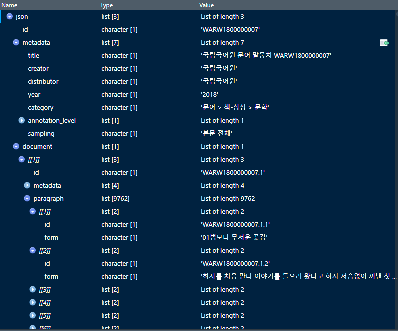

View() 함수를 이용하여 json_obj를 출력

#### 일상 대화 말뭉치의 구조

일상 대화 말뭉치 파일을 열어서 구조를 살펴보면 다음과 같다.

```r
target_f <- "data/모두의말뭉치/국립국어원 일상 대화 말뭉치 2020(버전 1.2)/SDRW2000000001.json"
json_obj <- read_json(target_f)

print(str(json_obj, max.level = 5, nchar.max = 50, list.len = 4))
```

```
## List of 3
##  $ id      : chr "SDRW2000000001"
##  $ metadata:List of 7
##   ..$ title           : chr "국립국어원 구어 말뭉치 SDRW2000000001"
##   ..$ creator         : chr "국립국어원"
##   ..$ distributor     : chr "국립국어원"
##   ..$ year            : chr "2020"
##   .. [list output truncated]
##  $ document:List of 1
##   ..$ :List of 3
##   .. ..$ id       : chr "SDRW2000000001.1"
##   .. ..$ metadata :List of 7
##   .. .. ..$ title    : chr "2인 일상 대화"
##   .. .. ..$ author   : chr "개인 발화자"
##   .. .. ..$ publisher: chr "개인 발화 녹음"
##   .. .. ..$ date     : chr "20200602"
##   .. .. .. [list output truncated]
##   .. ..$ utterance:List of 479
##   .. .. ..$ :List of 7
##   .. .. .. ..$ id           : chr "SDRW2000000001.1.1.1"
##   .. .. .. ..$ form         : chr "저는 여행 다니는 것을"
##   .. .. .. ..$ original_form: chr "저는 여행 다니는 것을"
##   .. .. .. ..$ speaker_id   : chr "SD2000001"
##   .. .. .. .. [list output truncated]
##   .. .. ..$ :List of 7
##   .. .. .. ..$ id           : chr "SDRW2000000001.1.1.2"
##   .. .. .. ..$ form         : chr "굉장히 좋아하는데요."
##   .. .. .. ..$ original_form: chr "굉장히 좋아하는데요."
##   .. .. .. ..$ speaker_id   : chr "SD2000001"
##   .. .. .. .. [list output truncated]
##   .. .. ..$ :List of 7
##   .. .. .. ..$ id           : chr "SDRW2000000001.1.1.3"
##   .. .. .. ..$ form         : chr "그래가지고"
##   .. .. .. ..$ original_form: chr "그래가지고"
##   .. .. .. ..$ speaker_id   : chr "SD2000001"
##   .. .. .. .. [list output truncated]
##   .. .. ..$ :List of 7
##   .. .. .. ..$ id           : chr "SDRW2000000001.1.1.4"
##   .. .. .. ..$ form         : chr "스페인이나 뭐 영국"
##   .. .. .. ..$ original_form: chr "스페인이나 뭐 영국"
##   .. .. .. ..$ speaker_id   : chr "SD2000001"
##   .. .. .. .. [list output truncated]
##   .. .. .. [list output truncated]
## NULL
```

- 구조는 문어 말뭉치와 동일하게 파일의 id, 파일의 metadata, document 등 3개로 되어 있고, document 아래에 id, metadata, utterance 등 3개의 구조가 더 있는 것을 볼 수 있다. json 파일에서 추출해야 할 가장 중요한 정보인 텍스트 정보는 json > document > utterance > form (혹은 original_form) 항목에 있다.
- 대화 말뭉치는 두 명 이상의 발화가 포함되어 있으므로, 발화 텍스트 외에 발화자 정보도 필요하다. 발화자 정보는 speaker_id에 담겨 있다. 이 발화자 정보와 발화 내용을 같이 추출하면 A와 B의 대화문을 만들 수 있다.

#### 형태 분석 말뭉치의 구조

문어 말뭉치나 대화 말뭉치와 달리 형태 분석 말뭉치는 문장의 각 어절에 형태소 분석을 실시한 후 형태소 단위의 분절 정보까지 포함하고 있다. 따라서 파일의 구조가 보다 복잡할 것임을 짐작할 수 있다.  
**str()** 함수보다 **View()** 함수로 구조를 살펴보는 것이 편리하다. (**View()** 명령은 앞의 # 기호를 지우고 입력)

```r
target_f <- "data/모두의말뭉치/국립국어원 형태 분석 말뭉치(버전 1.0)/SXMP1902008031.json"
json_obj <- read_json(target_f)

# View(json_obj)
```

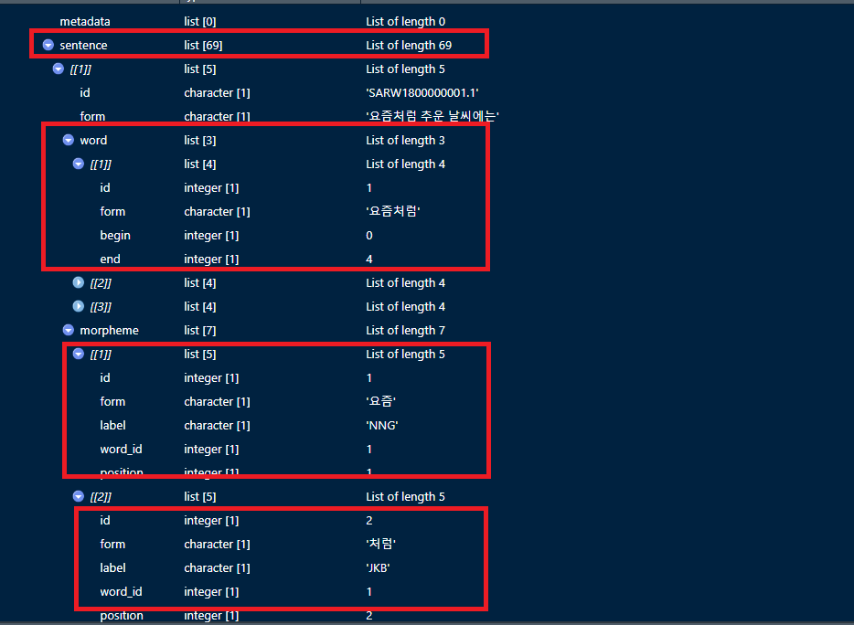

document > sentence > word / morpheme

#### json 파일의 내용에 접근하기

**read_json()**으로 읽은 json 파일은 이중 구조 혹은 다층 구조를 담을 수 있는 리스트(list) 형태로 저장된다.

```r
print(class(json_obj))
```

```
## [1] "list"
```

```r
print(names(json_obj))
```

```
## [1] "id"       "metadata" "document"
```

- 라인 1: **class()** 함수로 변수 *json_obj*의 유형을 확인한다.
- 라인 2: **names()** 함수로 리스트에 담긴 정보들의 이름을 확인한다. *json_obj*는 크게 (파일의) id, (파일의) metadata, document 등 3개의 요소로 이루어져 있다.

리스트 형태에 담긴 정보는 ‘$’ 기호나 [[‘요소 이름’]] 을 이용하여 접근한다.

```r
target_f <- "data/모두의말뭉치/국립국어원 문어 말뭉치(버전 1.0)/WARW1800000007.json"
json_obj <- read_json(target_f)

file_id <- json_obj$id
file_meta <- json_obj$metadata
file_document <- json_obj$document[[1]]

file_id1 <- json_obj[["id"]]
file_meta1 <- json_obj[["metadata"]]
file_document1 <- json_obj[["document"]][[1]]
```

- 라인 3: 파일의 id 정보만 가지고 와서 *file_id*에 할당한다.
- 라인 4: 파일의 metadata에 해당하는 정보만 가지고 와서 *file_meta*에 할당한다.
- 라인 5: 파일의 document에 해당하는 정보만 가지고 와서 *file_document*에 할당한다.
- 라인 6-8: [[ ]]를 이용하여 라인 3-5와 동일한 명령을 수행한다.

파일 id를 출력한다.

```r
print(file_id)
```

```
## [1] "WARW1800000007"
```

파일의 metadata를 출력한다.

```r
print(file_meta)
```

```
## $title
## [1] "국립국어원 문어 말뭉치 WARW1800000007"
##
## $creator
## [1] "국립국어원"
##
## $distributor
## [1] "국립국어원"
##
## $year
## [1] "2018"
##
## $category
## [1] "문어 > 책-상상 > 문학"
##
## $annotation_level
## $annotation_level[[1]]
## [1] "원시"
##
##
## $sampling
## [1] "본문 전체"
```

document는 하위에 또다른 구조(id, metadata, paragraph)를 담고 있으므로 **View()**나 **str()** 함수로 내용을 살펴볼 수 있다.

```r
str(file_document, max.level = 5, nchar.max = 50, list.len = 3)
```

```
## List of 3
##  $ id       : chr "WARW1800000007.1"
##  $ metadata :List of 4
##   ..$ title    : chr "이야기꾼 구연설화"
##   ..$ author   : chr "황인덕"
##   ..$ publisher: chr "박이정"
##   .. [list output truncated]
##  $ paragraph:List of 9762
##   ..$ :List of 2
##   .. ..$ id  : chr "WARW1800000007.1.1"
##   .. ..$ form: chr "01범보다 무서운 곶감"
##   ..$ :List of 2
##   .. ..$ id  : chr "WARW1800000007.1.2"
##   .. ..$ form: chr "화자를 처음 만나 이야기를 들으러 "| __truncated__
##   ..$ :List of 2
##   .. ..$ id  : chr "WARW1800000007.1.3"
##   .. ..$ form: chr "그링깨. 사람이 어거지루는 못 살구"| __truncated__
##   .. [list output truncated]
```

#### document 요소 살펴보기

*fie_document* 구조를 출력하면 텍스트 내용(문단/문장)은 “paragraph > form” 항목에 들어있는 것을 알 수 있다. 최종적으로 문단/문장 내용에 접근하려면 먼저 paragraph 정보를 가지고 온 후에 form 정보를 추출하면 된다. paragraph는 id와 form으로 구성된 리스트를 총 9762개 담고 있다.

```r
paragraphs <- file_document$paragraph

ids <- c()
sents <- c()

for (para in paragraphs) {
  id <- para[[1]]
  sent <- para[[2]]

  ids <- c(ids, id)
  sents <- c(sents, sent)
}

print(ids[1:5]); print(sents[1:5])
```

```
## [1] "WARW1800000007.1.1" "WARW1800000007.1.2" "WARW1800000007.1.3"
## [4] "WARW1800000007.1.4" "WARW1800000007.1.5"
```

```
## [1] "01범보다 무서운 곶감"
## [2] "화자를 처음 만나 이야기를 들으러 왔다고 하자 서슴없이 꺼낸 첫 이야기이다. 화자로서 가장 쉽게 기억해낸 이야기인 셈이다. 설화 앞뒤에 교훈적 해석을 덧붙이고 있음은 화자의 습관화된 태도의 한 모습이기도 하다. 어려서 조모로부터 들었다고 했다."
## [3] "그링깨. 사람이 어거지루는 못 살구. 응? 어거지루 안 되능 거여. 사람이 그링깨 뭐이냐 하먼 자연~간 제절루 되야지 어거지루는 못 살어, 사람이."
## [4] "그래 옛날, 그 꼭감이라능 게 말여. 사람이 먹잖야 이케? 먹지마는. 그게 참 무성(무서운) 거여."
## [5] "애기가 울어. 옛날에. 그래 할머니가 달갸(달래). 그때 호랭이가, 응? 그 집 문앜이 와 섰어 지금. 옛날이는 호랭이가 말두 하구 그랴. 그래 인제 그 할머니가 애기를 달램성 왼갖 소리를 다 햐. ‘호랭이 왔다’구 해두 울구우, ‘괭이 왔다’두 울구, 왼갖 소리를 다 해두 울어."
```

- 라인 1: 문단/문장을 담고 있는 paragraph 요소만 가지고 와서 변수 *paragraphs*에 할당한다.
- 라인 2, 3: 문단/문장의 id를 담을 변수 ids와, 문단/문장을 담을 변수 *sents*를 생성한다.
- 라인 4-10: **for** 문을 이용하여 *paragraphs*에 담긴 문단/문장 정보를 하나씩 가져온 후 id 정보와 sentence 정보를 각각 추출한 후 변수 *ids*와 *sents*에 순차적으로 넣는다.
- 라인 11: *ids*와 *sents*를 각각 5개씩 출력한다.

*paragraphs*의 개수와 *sents*의 개수가 동일한지 확인해 본다.

```r
print(length(paragraphs)); print(length(ids)); print(length(sents))
```

```
## [1] 9762
```

```
## [1] 9762
```

```
## [1] 9762
```

마지막으로 문단/문장만 일반 텍스트 파일로 내보내기를 한다.

```r
target_dir <- "data/모두의말뭉치/국립국어원 문어 말뭉치(버전 1.0)"
file_name <- paste0(file_id, ".txt")
file_name <- file.path(target_dir, file_name)
writeLines(text = sents, con = file_name)

print(file_name)
```

```
## [1] "data/모두의말뭉치/국립국어원 문어 말뭉치(버전 1.0)/WARW1800000007.txt"
```

텍스트 파일이 잘 생성되었는지 확인해 보려면 *target_dir*에서 확장자가 txt인 파일만 가져온 후 출력해 본다.

```r
txt_files <- list.files(path = target_dir, pattern = "txt")
print(txt_files)
```

```
## [1] "WARW1800000007.txt"
```

다른 말뭉치들도 위와 같은 방식으로 필요한 정보만 추출하여 새로운 파일로 만들면 된다.